# Practicle Machine Learning

## Assignment writeup

### Introduction

This is document describes the analysis that I conducted for the final project for the Coursera course “Practical Machine Learning” in the Data Science specialization track. The data for this assignment comes from https://d396qusza40orc.cloudfront.net/predmachlearn/pml-training.csv and https://d396qusza40orc.cloudfront.net/predmachlearn/pml-testing.csv, and contains information from belt, forearm, arm, and dumbbell accelerometers. The data are split into a training group (19,622) observations and testing group (20 observations). Participants in this study were asked to do a “Dumbbell Biceps Curl” in five different ways, including using correct form and four common mistakes. Participants were equipped with censors on the arm, belt and dumbbell itself.

### Method

Split the training set into 90/10 subsamples.

```r
library(lattice)
library(ggplot2)
library(caret)
pml.training <- read.csv("pml-training.csv")
set.seed(5000)
inTrain <- createDataPartition(y=pml.training$classe, p=0.9, list=FALSE)
training <- pml.training[inTrain,]
testing <- pml.training[-inTrain,]
```

The 90 percent subsample is used to train the model, and the 10 percent sample is used for cross-validation. The simple cross-validation was chosen over K-fold via the cv.folds option to cut down on execution time. The Stochastic Gradient Boosting algorithm via the gbm package was implemented.

```r
pm <- proc.time()
modFit <- train(classe ~ user_name + pitch_arm + yaw_arm + roll_arm + roll_belt + pitch_belt + yaw_belt + gyros_belt_x + gyros_belt_y + gyros_belt_z + accel_belt_x + accel_belt_y + accel_belt_z + magnet_belt_x + magnet_belt_y + magnet_belt_z + gyros_arm_x + gyros_arm_y + gyros_arm_z + accel_arm_x + accel_arm_y + accel_arm_z + magnet_arm_x + magnet_arm_y + magnet_arm_z + roll_dumbbell + pitch_dumbbell + yaw_dumbbell, method="gbm", data=training, verbose=FALSE)
proc.time() - pm
```

```
##    user  system elapsed
## 1301.93    2.55 1305.60
```

```r
print(modFit)
```

[output not shown]

```r
predict.train <- predict(modFit,training)
table(predict.train, training$classe)
```

```
##
## predict.train    A    B    C    D    E
##             A 4742  131   54   49   42
##             B   83 3162  120   13   41
##             C   54  105 2842  120   19
##             D  100    7   57 2694   13
##             E   43   13    7   19 3132
```

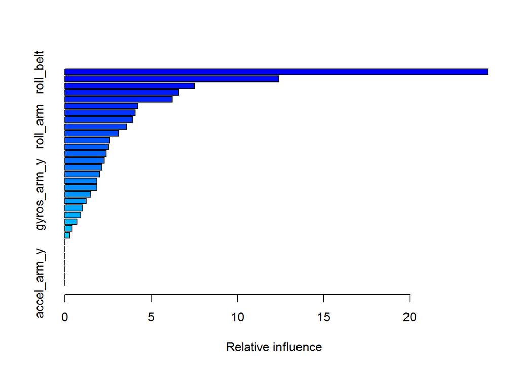

```
##                                 var rel.inf
## roll_belt                 roll_belt 24.5086
## yaw_belt                   yaw_belt 12.3988
## magnet_belt_z         magnet_belt_z  7.5005
## roll_dumbbell         roll_dumbbell  6.6061
## pitch_belt               pitch_belt  6.2146
## magnet_arm_z           magnet_arm_z  4.2399
## magnet_arm_x           magnet_arm_x  4.0873
## accel_arm_x             accel_arm_x  3.9440
## roll_arm                   roll_arm  3.5921
## gyros_belt_z           gyros_belt_z  3.1245
## yaw_dumbbell           yaw_dumbbell  2.5968
## pitch_dumbbell       pitch_dumbbell  2.5315
## accel_arm_z             accel_arm_z  2.4047
## pitch_arm                 pitch_arm  2.2843
## user_nameeurico     user_nameeurico  2.1446
## yaw_arm                     yaw_arm  2.0186
## magnet_belt_x         magnet_belt_x  1.8564
## accel_belt_z           accel_belt_z  1.8519
## gyros_arm_y             gyros_arm_y  1.5021
## magnet_arm_y           magnet_arm_y  1.2414
## magnet_belt_y         magnet_belt_y  1.0387
## user_namecharles   user_namecharles  0.9134
## gyros_belt_y           gyros_belt_y  0.6895
## gyros_arm_x             gyros_arm_x  0.4316
## gyros_belt_x           gyros_belt_x  0.2782
## user_namecarlitos user_namecarlitos  0.0000
## user_namejeremy     user_namejeremy  0.0000
## user_namepedro       user_namepedro  0.0000
## accel_belt_x           accel_belt_x  0.0000
## accel_belt_y           accel_belt_y  0.0000
## gyros_arm_z             gyros_arm_z  0.0000
## accel_arm_y             accel_arm_y  0.0000
```

```r
summary(modFit,n.trees=150)
```

A plot of these top two features colored by outcome demonstrates their relative importance.

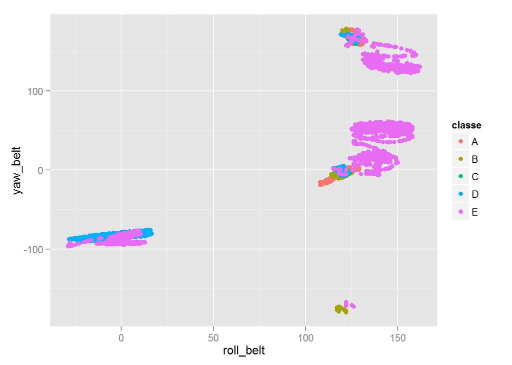

```r
qplot(roll_belt, yaw_belt,colour=classe,data=training)
```

Although these two variables are the most influencial, there are some bunching in the plot confirming the boosting algorithm as a good choice given the large set of relatively weak predictors.The next plot further demonstrates the improved performance gained by using boosting iterations.

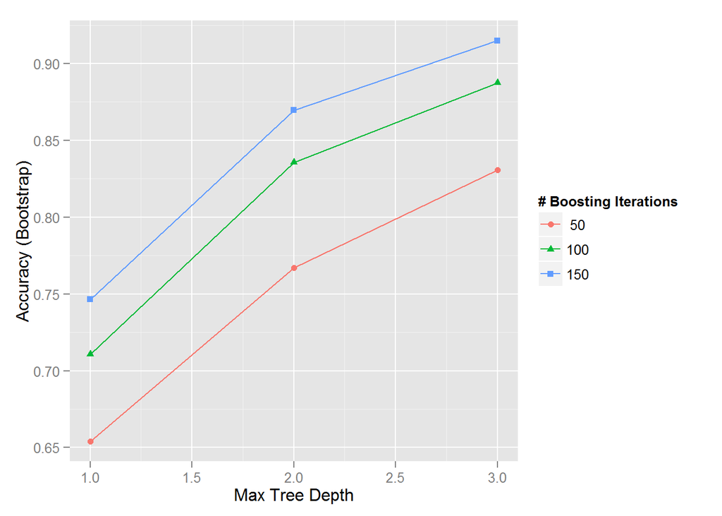

```r
ggplot(modFit)
```

The performance on the 10 percent subsample is further checked to get an estimate of the algorithms out-of-sample performance.

```r
predict.testing <- predict(modFit,testing)
table(predict.testing, testing$classe)
```

```
##
## predict.testing   A   B   C   D   E
##               A 513  19  10   2   6
##               B  13 343  19   7   6
##               C   8  10 305  13   4
##               D  16   2   6 296   1
##               E   8   5   2   3 343
```

Now, the performance of the algorithm is slightly worsened than comared to the 90 percent of the training set.

#### Predicting on the Test Set

Finally, The algorithm was used to predict the testing dataset provided, where the results were run through the **pml_write_files()** function provided by the course instructors, and were stored for submission.

```r
pml.testing <- read.csv("pml-testing.csv")
answers <- as.character(predict(modFit, pml.testing))
pml_write_files = function(x){
  n = length(x)
  for(i in 1:n){
    filename = paste0("problem_id_",i,".txt")
    write.table(x[i],file=filename,quote=FALSE,row.names=FALSE,col.names=FALSE)
  }
}
pml_write_files(answers)
```

Upon submission, the algorithm correctly predicted the outcome for 20/20 observations further confirming its strong out-of-sample classification accuracy.